# Assignment 3 - Due Wednesday, September 23rd at 11:59pm ET

Complete the code cells in this Jupyter notebook, and submit the final .ipynb notebook to Gradescope

- Make sure you save your changes in VS Code before uploading it (beware of the little "dot" in the tab above)
- You should **execute all code cells** before saving and submitting. We need to see the outputs/figures generated by Python

**(a)** In the cell below, 4 string variables are defined with the name of the Academy Award for Best Picture winner for the years 2022-2025. Additionally, 4 list variables are defined that contain the names of the Best Picture runners-up for the same years.

1. Use the defined variables and list concatenation to create variables named "nominees_2025", "nominees_2024", "nominees_2023", and "nominees_2022". Element zero of each list should be the name of the Best Picture Winner, followed by all the runners-up for that year.
2. Create a new list variable called "oscars_2022_2025" where each element is one of the lists you created in step 1. Element zero of the list should be the nominees from 2025, followed by the list of nominees in 2024, 2023, and 2022.
3. Using double indexing "[ ][ ]" on oscars_2022_2025, print the name of the 2024 Best Picture winner to the screen.
- You should **not** retype any of the strings below manually in your solution.

```python
winner_2025 = "One Battle After Another"
winner_2024 = "Anora"
winner_2023 = "Oppenheimer"
winner_2022 = "Everything Everywhere All at Once"

runner_up_2025 = ["Bugonia", "F1", "Frankenstein", "Hamnet",
    "Marty Supreme", "The Secret Agent", "Sentimental Value",
    "Sinners", "Train Dreams"]

runner_up_2024 = ["The Brutalist", "A Complete Unknown", "Conclave",
    "Dune: Part Two", "Emilia Pérez", "I'm Still Here",
    "Nickel Boys", "The Substance", "Wicked"]

runner_up_2023 = ["American Fiction", "Anatomy of a Fall", "Barbie",
    "The Holdovers", "Killers of the Flower Moon", "Maestro",
    "Past Lives", "Poor Things", "The Zone of Interest"]

runner_up_2022 = ["All Quiet on the Western Front", "Avatar: The Way of Water",
    "The Banshees of Inisherin", "Elvis", "The Fabelmans", "Tár",
    "Top Gun: Maverick", "Triangle of Sadness", "Women Talking"]


### your code here

nominees_2025 = [winner_2025] + runner_up_2025
nominees_2024 = [winner_2024] + runner_up_2024
nominees_2023 = [winner_2023] + runner_up_2023
nominees_2022 = [winner_2022] + runner_up_2022

oscars_2022_2025 = [nominees_2025, nominees_2024, nominees_2023, nominees_2022]

best_pic_2024 = oscars_2022_2025[1][0]
print(best_pic_2024)
```

```
Anora
```

**(b)** The code cell below demonstrates the use of the `.index` method. The integer "14" is the element in position 4 of "my_tuple":

```python
my_tuple = (32, 77, 19, 0, 14, 27)

print("The number 14 can be found in position:")
print(my_tuple.index(14))
```

```
The number 14 can be found in position:
4
```

In the cell below, two variables are created:

- A tuple "student_ids" which contains the identification number of a set of students in a course.
- A list "midterm_grades" containing the percentage earned by the student on a midterm exam.

The entries of "midterm_grades" directly correspond to the entries of "student_ids". For example, the student with ID number A-592 scored a 97.3%, the student with ID number G-430 scored a 79.1%, etc.

A grader made a mistake and the student with ID number T-126 should have scored a 73.2%. Fix the mistake as follows:

1. Use the `.index` method to find the location of the student's ID number within the tuple "student_ids". Assign this value to a new variable called "student_index".
2. Use "student_index" to change the corresponding grade to the value 73.2

(You may want to print "midterm_grades" when you're done to verify your code worked correctly.)

```python
student_ids = ('A-592', 'G-430', 'Z-129', 'Q-458',
    'Z-510', 'T-126', 'U-581', 'S-627')

midterm_grades = [97.3, 79.1, 91.2, 89.0,
    95.2, 68.2, 74.3, 86.2]

# your code here

student_index = student_ids.index('T-126')
print(student_index)
midterm_grades[student_index] = 73.2

for grade in midterm_grades:
    print(grade)
```

```
5
97.3
79.1
91.2
89.0
95.2
73.2
74.3
86.2
```

**(c)** Compute a geometric formula:

The **frustum** of a cone is the shape formed when the top of a cone is cut off parallel to the base, leaving two circular faces of different radii. (Think of a lampshade or a bucket)

The formula for the volume of a frustum of a cone is:

$$V = \frac{1}{3}\pi h (r_1^2 + r_1 r_2 + r_2^2)$$

Where:

- $V$ is the volume of the cylinder
- $r_1$ is the radius of the bottom base
- $r_2$ is the radius of the top base
- $h$ is the height of the frustrum

Calculate $V$ when:

- $r_1 = 6$
- $r_2 = 3$
- $h = 10$

To get full points:

- Define Python variables corresponding to the values of $r_1$, $r_2$, and $h$ above.
- Use your variables to calculate the volume ($V$) using the formula above. This value should also be assigned to a variable.
- Print out the value of the computed volume to the screen.

**Note:** $\pi \neq 3.14$

```python
# your code here
import math

def cone_vol(r1: int, r2: int, h: int): #Could use floats, for our purposes int works
    return 1/3 * math.pi * h * (r1*r1 + r1*r2 + r2*r2)

r1, r2, h = 6, 3, 10

V = cone_vol(r1, r2, h)

print(V)
```

```
659.7344572538565
```

**(d)** Operations on Arrays

- Define an array "temps_c" using `numpy.array()`, assigning the following values of temperatures measured in degrees Celsius:  
  temps_c $= \begin{pmatrix} c_1 \\ c_2 \\ c_3 \\ c_4 \\ c_5 \end{pmatrix} = \begin{pmatrix} 0 \\ 10 \\ 20 \\ 30 \\ 40 \end{pmatrix}$
- Use element-by-element vector operations to compute a new array "temps_f" of the same size, converting the temperatures from Celsius to Fahrenheit:  
  temps_f $= \begin{pmatrix} f_1 \\[8pt] f_2 \\[8pt] f_3 \\[8pt] f_4 \\[8pt] f_5 \end{pmatrix} = \begin{pmatrix} c_1 \times \tfrac{9}{5} +32 \\[8pt] c_2 \times \tfrac{9}{5} +32 \\[8pt] c_3 \times \tfrac{9}{5} + 32 \\[8pt] c_4 \times \tfrac{9}{5} + 32 \\[8pt] c_5 \times \tfrac{9}{5} + 32\end{pmatrix} $
- Print the value of "temps_f" to the screen.
- Pass the variable "temps_f" to the function `numpy.mean()` to calculate the average of the Fahrenheit temperatures.

```python
# your code here
import numpy as np
temps_c = np.array([0,10,20,30,40])

temps_f = temps_c * (9/5) + 32

print(temps_c)
print(temps_f)

fahren_mean = np.mean(temps_f)

print(fahren_mean)
```

```
[ 0 10 20 30 40]
[ 32.  50.  68.  86. 104.]
68.0
```

**(e)** Using NumPy arrays, create a **line** plot of the function

$$f(x) = \frac{1}{\sqrt{2\pi}}\mathrm{e}^{-x^2}$$

at a set of 75 evenly spaced points in the interval $-3 \leq x \leq 3$ using `numpy.linspace()`.

Label the axes and give it a title (this is the probability density function (pdf) of the standad normal probability distribution). Don't forget to suppress extraneous output with `plt.show()`

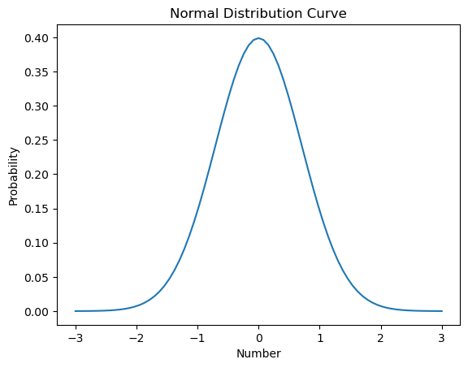

```python
# your code here
import matplotlib.pyplot as plt

def normal_dist(x: float): #Same thing, could use float
    return np.exp(-x**2) / np.sqrt(2 * math.pi)


func_x = np.linspace(-3, 3, num=75, endpoint=True)
func_y = normal_dist(func_x)

plt.xlabel("Number")
plt.ylabel("Probability")
plt.title("Normal Distribution Curve")
plt.plot(func_x, func_y)
plt.show()
```